# BIOS 667 - Lecture 12: Marginal Models (Ch. 12)

Fitzmaurice, Laird & Ware (2011) - Applied Longitudinal Data Analysis

Naim Rashid

## Lecture Objectives

- Understand why standard **GLMs** fail for longitudinal data
- Define **marginal models** and when to use them
- Distinguish **marginal vs mixed** model interpretations of $\beta$
- Describe the **three-part** marginal model: mean, variance, association
- Preview **GEE** estimation (Ch. 13) and apply it to a real Case Study

## Prerequisites: What You Should Recall

**Recall before we start**

- **L11 (Ch. 11):** the GLM building blocks: a **link** $g(\mu)$, a **variance function** $v(\mu)$, and a **dispersion** $\phi$. Logistic, Poisson, and linear models are all special cases.
- **L07/L08 (Ch. 7-8):** modeling **within-subject correlation** with a working/covariance structure (we used `gls()` with `corAR1`/`corCompSymm`). Same idea returns here as the *working correlation*.
- **L05 (Ch. 5):** population-average mean trajectories by group.

Today we glue these together: a GLM mean model **plus** a within-subject association structure, fit so that inference stays valid.

## Roadmap

1. Why GLMs fail for correlated data
2. Marginal model: **mean | variance | association**
3. Outcome-type specifications (continuous, count, binary, ordinal)
4. **Case Study:** epilepsy seizure counts (Poisson GEE)
5. Why full likelihood is hard for discrete data
6. GEE preview, missing-data caveat, practical decisions

## Notation reference

| Symbol | Meaning |
| --- | --- |
| $Y_{ij}$ | response for subject $i$ at occasion $j$ (scalar) |
| $\mathbf{Y}_i$ | response vector for subject $i$ $(n_i \times 1)$ |
| $\mathbf{X}_i,\ \boldsymbol\beta$ | fixed-effect design $n_i \times p$ and coefficients |
| $\mathbf{Z}_i,\ \mathbf{b}_i$ | random-effect design and random effects, $\mathbf{b}_i \sim N(0, G)$ |
| $G$ | between-subject random-effects covariance (FLW’s letter, Ch. 8) |
| $R_i$ | within-subject residual covariance, $\boldsymbol\varepsilon_i \sim N(0, R_i)$ |
| $\Sigma_i = \mathbf{Z}_i G \mathbf{Z}_i^\top + R_i$ | marginal (total) covariance $\operatorname{Cov}(\mathbf{Y}_i)$ for subject $i$ |
| $\rho$ | correlation parameter (AR(1), exchangeable) |

Indices: $i$ subject $1,\dots,N$; $j$ occasion/time $1,\dots,n_i$ ($n$ when balanced); $k$ state (transition models); $g$ group. **Bold** = vector or matrix.

## Notation (this lecture): GEE working covariance

This is the deck that **introduces** the GEE working-covariance notation. Reserved symbols ($R_i$ = within-subject **residual** covariance) are unchanged.

| Symbol | Meaning |
| --- | --- |
| $\pi_{ij}$ | binary response probability for subject $i$ at occasion $j$ |
| $\phi$ | dispersion (scale) parameter |
| $\alpha$ | working-**correlation** parameter (e.g. exchangeable $\rho$, AR(1) decay) |
| $\operatorname{Corr}_i(\alpha)$ | working correlation matrix $(n_i \times n_i)$ |
| $A_i$ | diagonal matrix of marginal variances $\phi\, v(\mu_{ij})$ |
| $V_i(\alpha) = A_i^{1/2}\,\operatorname{Corr}_i(\alpha)\,A_i^{1/2}$ | GEE **working covariance** of $\mathbf{Y}_i$ |

**Warning**

We write the working structure as $V_i(\alpha)$, and we do **not** reuse the symbol $R_i$ for it: $R_i$ is reserved for the residual covariance of the Gaussian LME. The ordinal cumulative-logit **thresholds** are written $\kappa_k$ to avoid colliding with the working-correlation $\alpha$.

## Motivation

Repeated measures within a subject are **correlated**.

A naive GLM assumes independence, so its inference is **invalid**: the standard errors are **incorrect** (FLW pp. 43-44).

**Note**

For **discrete** data, *how* we model correlation also changes the meaning of $\beta$.

## Two Model Families (FLW Ch. 12)

FLW Ch. 12 contrasts **two** families: marginal (population-average) vs mixed (subject-specific).

| Family | Target | $\beta$ Interpretation |
| --- | --- | --- |
| **Marginal** | Population mean | Population-average effect |
| **Mixed** | Individual trajectory | Subject-specific (given $b_i$) |
| *Transition* (preview) | Conditional on past $Y$ | Effect given previous outcomes |

**Note**

**Transition models** are a third family but are **not** part of FLW Ch. 12. Shown greyed as a forward pointer (transition-models lecture / FLW transition chapter).

## Marginal Model = Mean + Variance + Association

**Mean:**

$$E(Y_{ij}\mid X_{ij})=\mu_{ij}, \quad g(\mu_{ij})=X_{ij}\beta$$

**Variance:**

$$\operatorname{Var}(Y_{ij}\mid X_{ij})=\phi\,v(\mu_{ij})$$

**Association:**

Within-subject dependence via the working covariance $V_i(\alpha)$ (exchangeable, AR(1), etc.).

## Key Insight: Working Correlation

Changing $V_i(\alpha)$ affects **precision**, not the **interpretation** of $\beta$.

This is the defining feature of marginal models: $\beta$ targets the same population-average quantity regardless of the working correlation, and **robust (sandwich) SEs** stay valid even if $V_i(\alpha)$ is misspecified.

**Check Your Understanding: Marginal Model Foundations**

1. What is the key difference between marginal and mixed model interpretations of $\beta$?
2. Why does ignoring within-subject correlation give invalid inference for longitudinal data?
3. If you change the working correlation structure in a marginal model, what changes and what stays the same?

**Answers:**

## 12.2 Notation and Data Structure

- $N$ subjects; subject $i$ has $n_i$ measurements at times $t_{ij}$
- Stack responses: $\mathbf{Y}_i=(Y_{i1},\dots,Y_{in_i})^\top$
- Across-subject independence
- Within-subject dependence

## Covariates

$X_{ij}$ is the $1\times p$ covariate row; stack the rows to $X_i$ ($n_i\times p$)

| Type | Examples |
| --- | --- |
| **Time-invariant** | Treatment, sex (between-subject) |
| **Time-varying** | Age, exposure (within-subject) |

## Discrete Outcomes: Correlation Is Constrained

For binary outcomes the feasible correlation depends on the marginal means. With $p_1=E(Y_1)=0.2$ and $p_2=E(Y_2)=0.8$:

The largest possible $\Pr(Y_1=1, Y_2=1)$ is $\min(p_1,p_2)=0.2$ (the Frechet bound):

|  | $Y_2=0$ | $Y_2=1$ | margin |
| --- | --- | --- | --- |
| $Y_1=0$ | $0.2$ | $0.6$ | $0.8$ |
| $Y_1=1$ | $0.0$ | $0.2$ | $0.2$ |
| margin | $0.2$ | $0.8$ |  |

At that maximum, the correlation is
$$\rho_{12}^{\max}=\sqrt{\frac{p_1(1-p_2)}{p_2(1-p_1)}}=\sqrt{\frac{0.2\cdot 0.2}{0.8\cdot 0.8}}=\sqrt{\tfrac{0.04}{0.64}}=0.25.$$

So $\rho_{12}\le 0.25$: the means alone **cap** the correlation.

## Discrete Outcomes: Odds Ratios Are More Natural

For a pair of binary outcomes, define the four joint cell probabilities:

|  | $Y_k=0$ | $Y_k=1$ |
| --- | --- | --- |
| $Y_j=0$ | $P_{00}$ | $P_{01}$ |
| $Y_j=1$ | $P_{10}$ | $P_{11}$ |

The pairwise **log odds ratio** uses these cells directly:

$$\theta_{jk}=\log\frac{P_{11}\,P_{00}}{P_{10}\,P_{01}}$$

Unlike the correlation, the odds ratio is **not** mechanically bounded by the marginal means, so it is the more natural association measure for binary data.

## Master Simulated Dataset: continuous outcome

A small simulated dataset to illustrate the long format and the continuous fit. The continuous outcome carries **subject random effects** ($b_0, b_1$), so it is genuinely correlated within subject.

```r
suppressPackageStartupMessages({
  library(dplyr); library(tidyr); library(tibble)
  library(ggplot2); library(nlme); library(broom); library(geepack)
})

set.seed(667)
N <- 120
n_i  <- sample(3:6, N, replace = TRUE)
id   <- rep(1:N, times = n_i)
time <- unlist(lapply(n_i, function(n) 0:(n - 1)))
trt  <- rep(rbinom(N, 1, 0.5), times = n_i)

# subject random effects induce within-subject correlation
b0 <- rep(rnorm(N, 0, 1.2), times = n_i)
b1 <- rep(rnorm(N, 0, 0.4), times = n_i)
y  <- 10 + 0.6 * time + 1.0 * trt + 0.5 * (trt * time) +
      b0 + b1 * time + rnorm(length(id), 0, 1)
```

## Master Simulated Dataset: discrete outcomes

```r
# Discrete outcomes generated INDEPENDENT within subject (illustration only)
lp_bin  <- -1 + 0.25 * time + 0.7 * trt
y_bin   <- rbinom(length(id), 1, plogis(lp_bin))

mu_cnt  <- exp(1.2 + 0.15 * time + 0.3 * trt)
y_count <- rpois(length(id), mu_cnt)

cuts <- quantile(y, probs = c(.25, .5, .75))
ordinal_y <- cut(y, breaks = c(-Inf, cuts, Inf),
                 labels = c("L", "M", "H", "VH"), ordered_result = TRUE)

dat <- tibble(
  id   = factor(id),
  time = as.integer(time),
  trt  = factor(trt, levels = c(0, 1), labels = c("Ctl", "Tx")),
  y = y, y_bin = as.integer(y_bin),
  y_count = as.integer(y_count), ordinal_y = ordered(ordinal_y)
)
```

**Warning**

`y_bin` and `y_count` are generated **independent within subject** (no random effect), so they understate the correlation the lecture motivates. They illustrate the *specification* only. The real correlated discrete analysis is the epilepsy Case Study below.

## Long Format: One Subject’s Rows

```r
head(dat, 8)
```

## Long Format: One Subject’s Rows

```
# A tibble: 8 × 7
  id     time trt       y y_bin y_count ordinal_y
  <fct> <int> <fct> <dbl> <int>   <int> <ord>
1 1         0 Ctl   11.5      1       3 M
2 1         1 Ctl   12.4      1       5 H
3 1         2 Ctl   13.0      1       2 H
4 2         0 Tx    10.8      0       2 M
5 2         1 Tx    12.7      0       3 H
6 2         2 Tx    13.2      0       8 H
7 2         3 Tx    16.0      0       6 VH
8 3         0 Tx     8.77     0       7 L
```

## Visualizing Imbalance

```r
ggplot(dat, aes(time, y, group = id, color = trt)) +
  geom_line(alpha = 0.15) +
  stat_summary(aes(group = trt), fun = mean, geom = "line", linewidth = 1.2) +
  labs(title = "Unbalanced Trajectories by Treatment (continuous y)",
       y = "Continuous outcome y") +
  theme_minimal()
```

## Visualizing Imbalance

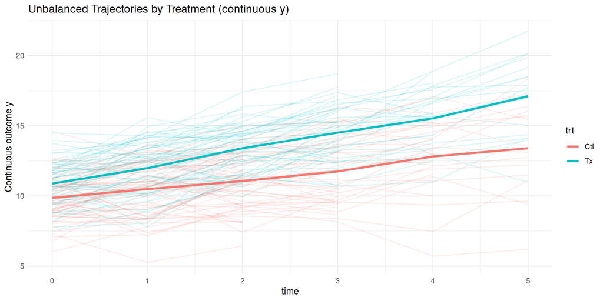

## Implicit Mean Assumption

The marginal mean depends only on the **current** covariate:

$$E(Y_{ij}\mid X_{i1},\dots,X_{in_i})=E(Y_{ij}\mid X_{ij})$$

This holds for **design-fixed covariates** (fixed by the study design, e.g. randomized treatment, planned visit time).

```
   time ->        X_1  ->  Y_1     X_2  ->  Y_2     X_3  ->  Y_3
                            |                |
   FORBIDDEN feedback:      +----> X_2        +----> X_3   (Y_(j-1) -> X_j)
```

It **fails** when a future covariate responds to a past outcome (feedback), e.g. a clinician raising the dose after a poor prior response.

## Outcome-Type Specifications (one table)

All four use the same three-part recipe; only the link and variance function change.

| Outcome | Link $g(\mu)$ | Variance $v(\mu)$ | $\beta$ interpretation |
| --- | --- | --- | --- |
| **Continuous** | identity $\mu$ | $\phi$ (constant) | population-avg mean difference / slope |
| **Count** | log $\log\mu$ | $\phi\,\mu$ | population-avg log **rate ratio** |
| **Binary** | logit $\log\frac{\mu}{1-\mu}$ | $\mu(1-\mu)$ | population-avg log **odds ratio** |
| **Ordinal** | cumulative logit | (multinomial) | population-avg log **cumulative-odds ratio** |

Association in every row: a working covariance $V_i(\alpha)$ (exchangeable, AR(1), unstructured, …).

## Ordinal Specification (Proportional Odds)

Genuinely new structure: cumulative dichotomizations with shared slopes.

$$\Pr(Y_{ij}\le k\mid X_{ij})=F_{ijk}, \qquad
\log\frac{F_{ijk}}{1-F_{ijk}}=\kappa_k - X_{ij}\beta$$

- $\kappa_k$: category-specific **thresholds** (cut-points), $\kappa_1<\dots<\kappa_{K-1}$ (FLW writes these $\alpha_k$; we use $\kappa_k$ to keep $\alpha$ for the GEE working correlation)
- $\beta$: population-average log **cumulative-odds ratios**, shared across cut-points (the proportional-odds assumption); the **minus-sign** form matches L11 and R’s `polr`, so a positive $\beta$ pushes toward higher categories

**Warning**

A proper **marginal** ordinal fit needs **GEE for cumulative logits** (e.g. `multgee::ordLORgee`, `repolr`) to account for within-subject clustering. An ordinary `MASS::polr` fit assumes independence and gives the wrong SEs, so we defer the worked ordinal fit to **L13**. Here we present only the specification.

## GEE bridge: how to read `geeglm` (estimation is L13)

**Reading a `geeglm` call before we derive GEE**

The **estimation machinery** (estimating equations, the sandwich variance) is **next lecture (L13)**. For now, read a `geepack::geeglm` fit as a black box:

- `id =` is the **clustering variable** (which rows belong to the same subject)
- `corstr =` is the **working correlation** (`"exchangeable"`, `"ar1"`, `"independence"`, …)
- the printed **`Std.err` IS the robust / sandwich SE** (valid even if `corstr` is misspecified)

## Continuous Outcome: Fit (`gls`)

```r
dat_cont <- dat |> dplyr::select(id, time, trt, y)

fit_cont <- gls(
  y ~ time * trt,
  data = dat_cont,
  correlation = corAR1(form = ~ time | id),
  method = "REML"
)

coef(summary(fit_cont))
```

## Continuous Outcome: Fit (`gls`)

```
                Value  Std.Error   t-value       p-value
(Intercept) 9.8480676 0.25177579 39.114434 6.794428e-159
time        0.6358133 0.08095063  7.854335  2.221246e-14
trtTx       1.0093787 0.35894546  2.812067  5.103470e-03
time:trtTx  0.6150262 0.11373305  5.407630  9.648125e-08
```

## Continuous: Plain-Language Interpretation

[output not shown]

**In a sentence:** both groups increase over time, but the treatment group starts higher and increases faster, so the separation grows.

## Case Study: Epilepsy Seizure Counts

**The data (FLW Ch. 12-14 canonical discrete example)**

A placebo-controlled trial of the anti-epileptic drug **progabide** in 59 patients with partial seizures (Thall & Vail 1990; FLW Ch. 12-14). Seizure counts were recorded over four successive **2-week** post-randomization intervals, plus an **8-week baseline** count.

- **Outcome:** `seizures` (count) at visits 1-4
- **Covariates:** `trt` (placebo / progabide), log baseline rate, visit
- **Question:** does progabide reduce the seizure **rate** vs placebo?

## Case Study: Load and Reshape (wide -> long)

```r
epi_url  <- "https://content.sph.harvard.edu/fitzmaur/ala2e/epilepsy.txt"
epi_file <- "../../data/epilepsy.txt"
if (!file.exists(epi_file)) {
  dir.create(dirname(epi_file), showWarnings = FALSE, recursive = TRUE)
  download.file(epi_url, epi_file)
}

# FLW .txt has a comment header; data rows start at the first "<int> <int> ..."
raw <- readLines(epi_file)
data_start <- grep("^\\s*[0-9]+\\s+[0-9]", raw)[1]
epi_wide <- read.table(text = raw[data_start:length(raw)])
names(epi_wide) <- c("id", "trt", "age", "baseline", "c1", "c2", "c3", "c4")

epi <- epi_wide |>
  tidyr::pivot_longer(c(c1, c2, c3, c4),
                      names_to = "visit", values_to = "seizures") |>
  dplyr::mutate(
    visit = as.integer(gsub("c", "", visit)),
    trt   = factor(trt, levels = c(0, 1),
                   labels = c("Placebo", "Progabide")),
    lbase = log(baseline / 4)   # 8-wk baseline -> per-2-wk rate scale
  )

head(epi, 6)
```

## Case Study: Load and Reshape (wide -> long)

```
# A tibble: 6 × 7
     id trt       age baseline visit seizures lbase
  <int> <fct>   <int>    <int> <int>    <int> <dbl>
1     1 Placebo    31       11     1        5  1.01
2     1 Placebo    31       11     2        3  1.01
3     1 Placebo    31       11     3        3  1.01
4     1 Placebo    31       11     4        3  1.01
5     2 Placebo    30       11     1        3  1.01
6     2 Placebo    30       11     2        5  1.01
```

## Case Study: Marginal Poisson GEE

```r
fit_epi <- geeglm(
  seizures ~ trt + lbase,
  id      = id,
  data    = epi,
  family  = poisson(link = "log"),
  corstr  = "exchangeable"
)

summary(fit_epi)
```

## Case Study: Marginal Poisson GEE

```
Call:
geeglm(formula = seizures ~ trt + lbase, family = poisson(link = "log"),
    data = epi, id = id, corstr = "exchangeable")

 Coefficients:
             Estimate Std.err   Wald Pr(>|W|)
(Intercept)   -0.3042  0.3651  0.694    0.405
trtProgabide  -0.1065  0.1940  0.301    0.583
lbase          1.1744  0.1487 62.390 2.78e-15 ***
---
Signif. codes:  0 '***' 0.001 '**' 0.01 '*' 0.05 '.' 0.1 ' ' 1

Correlation structure = exchangeable
Estimated Scale Parameters:

            Estimate Std.err
(Intercept)     4.82   1.155
  Link = identity

Estimated Correlation Parameters:
      Estimate Std.err
alpha   0.4051 0.07368
Number of clusters:   59  Maximum cluster size: 4
```

## Case Study: Rate Ratios and Interpretation

```r
est <- coef(summary(fit_epi))
rr  <- exp(cbind(RR = est[, "Estimate"],
                 Lower = est[, "Estimate"] - 1.96 * est[, "Std.err"],
                 Upper = est[, "Estimate"] + 1.96 * est[, "Std.err"]))
round(rr, 3)
```

**Interpretation (rate ratios, population-average):**

- **Progabide vs placebo:** $\widehat{RR}\approx 0.90$ (95% CI crosses 1) - no significant reduction in seizure rate once baseline is accounted for.
- **Log baseline:** $\widehat{RR}\approx 3.2$ per unit - the dominant predictor; higher baseline rate strongly predicts more post-randomization seizures.

## Case Study: Rate Ratios and Interpretation

```
        RR Lower Upper
[1,] 0.738 0.361 1.509
[2,] 0.899 0.615 1.315
[3,] 3.236 2.418 4.331
```

## Case Study: Model-Based vs Robust SEs

```r
# Naive Poisson GLM ignores clustering: model-based SEs
fit_naive <- glm(seizures ~ trt + lbase, data = epi,
                 family = poisson(link = "log"))

data.frame(
  term       = c("trtProgabide", "lbase"),
  naive_SE   = summary(fit_naive)$coef[c("trtProgabide", "lbase"), "Std. Error"],
  robust_SE  = coef(summary(fit_epi))[c("trtProgabide", "lbase"), "Std.err"]
) |> dplyr::mutate(ratio = round(robust_SE / naive_SE, 2))
```

**Warning**

The naive GLM SE for treatment is roughly **one-quarter** of the GEE robust SE: ignoring the within-subject correlation gives **invalid (overconfident) inference**. The point estimate barely moves; only the SEs change.

## Case Study: Model-Based vs Robust SEs

```
                     term naive_SE robust_SE ratio
trtProgabide trtProgabide  0.04527    0.1940  4.29
lbase               lbase  0.03084    0.1487  4.82
```

## The Same Model in SAS

Static reference (not run here): the marginal Poisson GEE in `PROC GENMOD` with a `REPEATED` statement.

```sas
proc genmod data=epi;
   class id trt;
   model seizures = trt lbase / dist=poisson link=log;
   repeated subject=id / type=exch corrw;
run;
```

**Note**

`repeated subject=id` is SAS’s `id=`; `type=exch` is `corstr="exchangeable"`. `corrw` prints the working correlation. SAS reports **empirical (robust) standard errors** by default, the same sandwich SE as `geeglm`’s `Std.err`.

## Why Full Likelihood Is Hard

```r
needed_terms <- function(m) 2^m - m - 1
dfc <- data.frame(m = 4:12, extra_assoc = sapply(4:12, needed_terms))

ggplot(dfc, aes(m, extra_assoc)) +
  geom_point() + geom_line() +
  scale_y_continuous(labels = scales::comma) +
  labs(title = "Explosion of Association Parameters",
       x = "Number of repeats (m)",
       y = "Parameters beyond means (2^m - m - 1)") +
  theme_minimal()
```

## Why Full Likelihood Is Hard

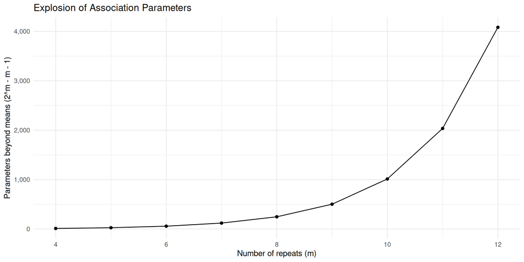

## Full Likelihood vs Marginal + GEE

| Approach | Challenge |
| --- | --- |
| **Full likelihood** | Needs 2-, 3-, … way associations (infeasible) |
| **Marginal + GEE** | Specify mean, variance, working $V_i(\alpha)$; robust SEs |

GEE wins for practicality and interpretability.

**Check Your Understanding: Specifications and the Case Study**

1. For a count outcome with a log link, what does $\beta$ represent in a marginal model?
2. In the epilepsy Case Study, the naive and robust SEs differed by ~4x but $\hat\beta$ barely moved. Why?
3. Why did we present the ordinal model but not fit it with `polr`?

**Answers:**

1. A population-average **log rate ratio**: $\exp(\beta)$ is the multiplicative change in the average event rate per unit covariate, across the population.
2. The point estimate is consistent regardless of the working correlation, so it is stable. The naive GLM assumes independence and badly underestimates the SE because the four visits per patient are strongly correlated; the GEE robust SE corrects this. Association affects **precision**, not the estimate.
3. `polr` assumes independence and ignores the within-subject clustering, giving the wrong (overconfident) SEs - the exact error this lecture warns against. A proper marginal ordinal fit needs GEE for cumulative logits (L13).

## Practical Decisions: Model Selection

| Question Type | Best Model |
| --- | --- |
| Population-average effects | Marginal (GEE) |
| Subject-specific trajectories | Mixed effects |
| *Dependence on past $Y$* (preview) | Transition model |

**Note**

The transition row is a **forward pointer** (not FLW Ch. 12); transition models are covered in their own lecture / FLW transition chapter.

## Looking Ahead (beyond Ch. 12): Missing Data

**Missing-data caveat (covered in L17, FLW Ch. 17-18)**

- **Standard GEE** requires data **MCAR** (missing completely at random) for valid inference.
- **IPW-GEE** (inverse-probability-weighted GEE; Robins, Rotnitzky & Zhao 1995) extends validity to **MAR** by weighting observations by the inverse probability of being observed and modeling the dropout process.
- The MCAR / MAR definitions and the IPW weighting mechanics are developed in **L17** (FLW Ch. 17-18). FLW Ch. 12 (p. 352) explicitly defers missing-data issues to those chapters.

## Common Mistakes in Marginal Models

| Mistake | Why It Is Wrong | Correct Approach |
| --- | --- | --- |
| Interpreting $\beta$ as subject-specific | Marginal $\beta$ is population-average | Use mixed models for subject-specific effects |
| Ignoring within-subject correlation | Gives invalid inference / incorrect SEs | Account for it via GEE or mixed models |
| Using standard GEE with MAR dropout | Standard GEE assumes MCAR (L17) | IPW-GEE or likelihood-based methods |
| Treating all outcome types the same | Binary/ordinal have constrained associations | Use the appropriate link and variance functions |
| Confusing efficiency with consistency | Wrong $V_i(\alpha)$ loses efficiency, not consistency | Choose sensible $V_i(\alpha)$; robust SEs protect |
| Assuming marginal $=$ conditional for non-linear links | They differ for logistic/Poisson (marginal attenuated vs conditional; **quantified in L14/L16, FLW Ch. 16**) | Be explicit about which target you mean |

## Key Takeaways

- Marginal model = **mean + variance + association** ($g$, $v(\mu)$, $V_i(\alpha)$)
- $\beta$ = **population-average** effect (log rate/odds ratio for count/binary), robust to the working correlation
- The working correlation $V_i(\alpha)$ affects **precision**, not interpretation; **robust SEs** stay valid
- Case Study (epilepsy): progabide $\widehat{RR}\approx 0.90$ (not significant); robust SEs ~4x the naive ones
- For discrete data, full joint likelihoods are intractable; use **GEE** (L13)
- Standard GEE assumes **MCAR**; missing-data extensions in **L17**

## Further Reading

- **FLW (2011) Ch. 12**, “Marginal Models: Introduction and Overview” (pp. 341-352), and its *Further Reading* section.
- **Liang, K.-Y. & Zeger, S.L. (1986).** Longitudinal data analysis using generalized linear models. *Biometrika* 73, 13-22. (The original GEE paper; estimation in L13.)
- **Robins, J.M., Rotnitzky, A. & Zhao, L.P. (1995).** Analysis of semiparametric regression models for repeated outcomes in the presence of missing data. *JASA* 90, 106-121. (IPW-GEE; missing data in L17.)
- **Thall, P.F. & Vail, S.C. (1990).** Some covariance models for longitudinal count data with overdispersion. *Biometrics* 46, 657-671. (The epilepsy data.)

**Next lecture (L13):** GEE estimation - the estimating equations, the sandwich variance, and choosing the working correlation.